# codebook

Autogenerated data summary from dataMaid

2018-06-14 18:40:04

# Data report overview

The dataset examined has the following dimensions:

| Feature | Result |
| --- | --- |
| Number of observations | 180 |
| Number of variables | 68 |

### Checks performed

The following variable checks were performed, depending on the data type of each variable:

|  | character | factor | labelled | numeric | integer | logical | Date |
| --- | --- | --- | --- | --- | --- | --- | --- |
| Identify miscoded missing values | × | × | × | × | × |  | × |
| Identify prefixed and suffixed whitespace | × | × | × |  |  |  |  |
| Identify levels with < 6 obs. | × | × | × |  |  |  |  |
| Identify case issues | × | × | × |  |  |  |  |
| Identify misclassified numeric or integer variables | × | × | × |  |  |  |  |
| Identify outliers |  |  |  | × | × |  | × |

Please note that all numerical values in the following have been rounded to 2 decimals.

# Summary table

|  | Variable class | # unique values | Missing observations | Any problems? |
| --- | --- | --- | --- | --- |
| subject | integer | 30 | 0.00 % |  |
| activity | factor | 6 | 0.00 % |  |
| timebodyaccmean_x | numeric | 180 | 0.00 % | × |
| timebodyaccmean_y | numeric | 180 | 0.00 % | × |
| timebodyaccmean_z | numeric | 180 | 0.00 % | × |
| timebodyaccstd_x | numeric | 180 | 0.00 % |  |
| timebodyaccstd_y | numeric | 180 | 0.00 % |  |
| timebodyaccstd_z | numeric | 180 | 0.00 % |  |
| timegravityaccmean_x | numeric | 180 | 0.00 % | × |
| timegravityaccmean_y | numeric | 180 | 0.00 % | × |
| timegravityaccmean_z | numeric | 180 | 0.00 % | × |
| timegravityaccstd_x | numeric | 180 | 0.00 % | × |
| timegravityaccstd_y | numeric | 180 | 0.00 % | × |
| timegravityaccstd_z | numeric | 180 | 0.00 % | × |
| timebodyaccjerkmean_x | numeric | 180 | 0.00 % | × |
| timebodyaccjerkmean_y | numeric | 180 | 0.00 % | × |
| timebodyaccjerkmean_z | numeric | 180 | 0.00 % | × |
| timebodyaccjerkstd_x | numeric | 180 | 0.00 % |  |
| timebodyaccjerkstd_y | numeric | 180 | 0.00 % |  |
| timebodyaccjerkstd_z | numeric | 180 | 0.00 % |  |
| timebodygyromean_x | numeric | 180 | 0.00 % | × |
| timebodygyromean_y | numeric | 180 | 0.00 % | × |
| timebodygyromean_z | numeric | 180 | 0.00 % | × |
| timebodygyrostd_x | numeric | 180 | 0.00 % |  |
| timebodygyrostd_y | numeric | 180 | 0.00 % |  |
| timebodygyrostd_z | numeric | 180 | 0.00 % |  |
| timebodygyrojerkmean_x | numeric | 180 | 0.00 % | × |
| timebodygyrojerkmean_y | numeric | 180 | 0.00 % | × |
| timebodygyrojerkmean_z | numeric | 180 | 0.00 % | × |
| timebodygyrojerkstd_x | numeric | 180 | 0.00 % |  |
| timebodygyrojerkstd_y | numeric | 180 | 0.00 % |  |
| timebodygyrojerkstd_z | numeric | 180 | 0.00 % |  |
| timebodyaccmagmean | numeric | 180 | 0.00 % |  |
| timebodyaccmagstd | numeric | 180 | 0.00 % |  |
| timegravityaccmagmean | numeric | 180 | 0.00 % |  |
| timegravityaccmagstd | numeric | 180 | 0.00 % |  |
| timebodyaccjerkmagmean | numeric | 180 | 0.00 % |  |
| timebodyaccjerkmagstd | numeric | 180 | 0.00 % |  |
| timebodygyromagmean | numeric | 180 | 0.00 % |  |
| timebodygyromagstd | numeric | 180 | 0.00 % |  |
| timebodygyrojerkmagmean | numeric | 180 | 0.00 % |  |
| timebodygyrojerkmagstd | numeric | 180 | 0.00 % |  |
| freqbodyaccmean_x | numeric | 180 | 0.00 % |  |
| freqbodyaccmean_y | numeric | 180 | 0.00 % |  |
| freqbodyaccmean_z | numeric | 180 | 0.00 % |  |
| freqbodyaccstd_x | numeric | 180 | 0.00 % |  |
| freqbodyaccstd_y | numeric | 180 | 0.00 % |  |
| freqbodyaccstd_z | numeric | 180 | 0.00 % |  |
| freqbodyaccjerkmean_x | numeric | 180 | 0.00 % |  |
| freqbodyaccjerkmean_y | numeric | 180 | 0.00 % |  |
| freqbodyaccjerkmean_z | numeric | 180 | 0.00 % |  |
| freqbodyaccjerkstd_x | numeric | 180 | 0.00 % |  |
| freqbodyaccjerkstd_y | numeric | 180 | 0.00 % |  |
| freqbodyaccjerkstd_z | numeric | 180 | 0.00 % |  |
| freqbodygyromean_x | numeric | 180 | 0.00 % |  |
| freqbodygyromean_y | numeric | 180 | 0.00 % |  |
| freqbodygyromean_z | numeric | 180 | 0.00 % |  |
| freqbodygyrostd_x | numeric | 180 | 0.00 % |  |
| freqbodygyrostd_y | numeric | 180 | 0.00 % |  |
| freqbodygyrostd_z | numeric | 180 | 0.00 % |  |
| freqbodyaccmagmean | numeric | 180 | 0.00 % |  |
| freqbodyaccmagstd | numeric | 180 | 0.00 % |  |
| freqbodyaccjerkmagmean | numeric | 180 | 0.00 % |  |
| freqbodyaccjerkmagstd | numeric | 180 | 0.00 % |  |
| freqbodygyromagmean | numeric | 180 | 0.00 % |  |
| freqbodygyromagstd | numeric | 180 | 0.00 % |  |
| freqbodygyrojerkmagmean | numeric | 180 | 0.00 % |  |
| freqbodygyrojerkmagstd | numeric | 180 | 0.00 % |  |

# Variable list

## subject

| Feature | Result |
| --- | --- |
| Variable type | integer |
| Number of missing obs. | 0 (0 %) |
| Number of unique values | 30 |
| Median | 15.5 |
| 1st and 3rd quartiles | 8; 23 |
| Min. and max. | 1; 30 |

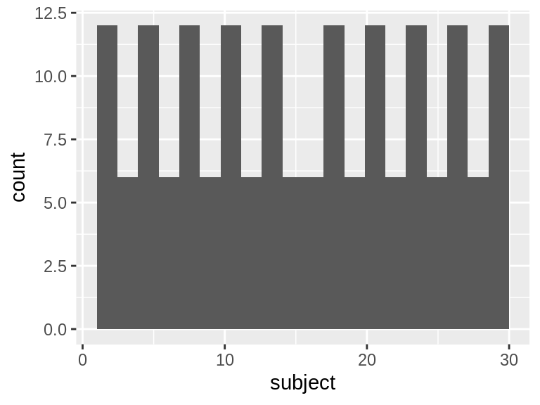

## activity

| Feature | Result |
| --- | --- |
| Variable type | factor |
| Number of missing obs. | 0 (0 %) |
| Number of unique values | 6 |
| Mode | “LAYING” |

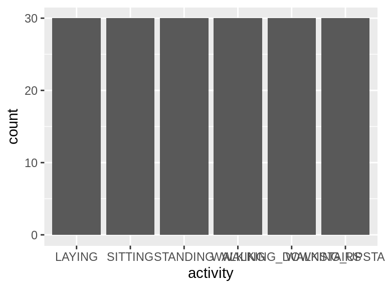

## timebodyaccmean_x

| Feature | Result |
| --- | --- |
| Variable type | numeric |
| Number of missing obs. | 0 (0 %) |
| Number of unique values | 180 |
| Median | 0.28 |
| 1st and 3rd quartiles | 0.27; 0.28 |
| Min. and max. | 0.22; 0.3 |

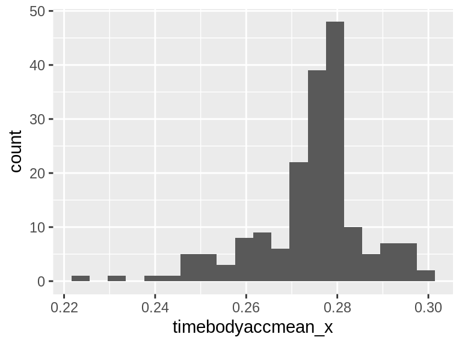

- Note that the following possible outlier values were detected: "0.22", "0.28", "0.28", "0.28", "0.28", "0.28", "0.28", "0.29", "0.29", "0.29" (18 additional values omitted).

## timebodyaccmean_y

| Feature | Result |
| --- | --- |
| Variable type | numeric |
| Number of missing obs. | 0 (0 %) |
| Number of unique values | 180 |
| Median | -0.02 |
| 1st and 3rd quartiles | -0.02; -0.01 |
| Min. and max. | -0.04; 0 |

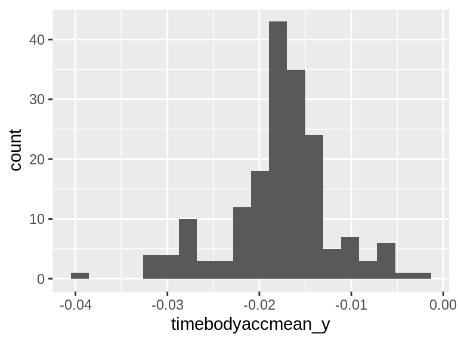

- Note that the following possible outlier values were detected: "-0.04", "-0.03", "-0.03", "-0.03", "-0.01", "-0.01", "-0.01", "-0.01", "-0.01", "-0.01" (12 additional values omitted).

## timebodyaccmean_z

| Feature | Result |
| --- | --- |
| Variable type | numeric |
| Number of missing obs. | 0 (0 %) |
| Number of unique values | 180 |
| Median | -0.11 |
| 1st and 3rd quartiles | -0.11; -0.1 |
| Min. and max. | -0.15; -0.08 |

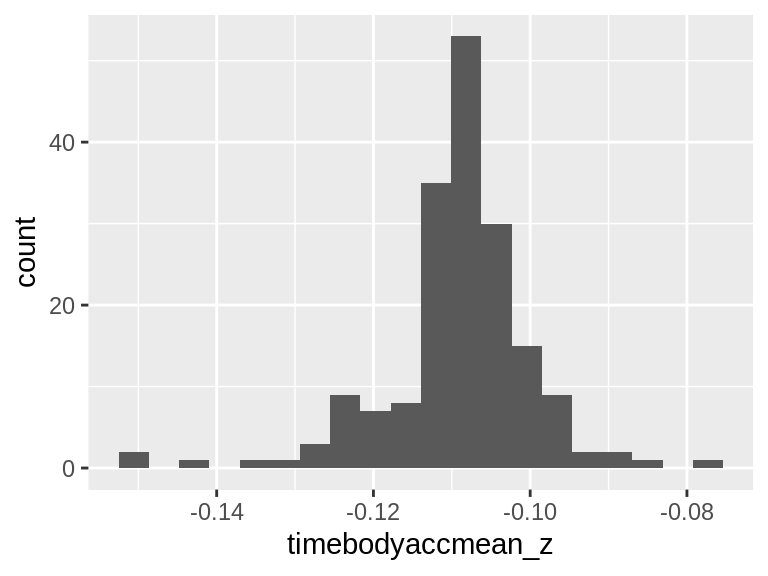

- Note that the following possible outlier values were detected: "-0.15", "-0.15", "-0.14", "-0.13", "-0.13", "-0.1", "-0.1", "-0.09", "-0.09", "-0.09" (3 additional values omitted).

## timebodyaccstd_x

| Feature | Result |
| --- | --- |
| Variable type | numeric |
| Number of missing obs. | 0 (0 %) |
| Number of unique values | 180 |
| Median | -0.75 |
| 1st and 3rd quartiles | -0.98; -0.2 |
| Min. and max. | -1; 0.63 |

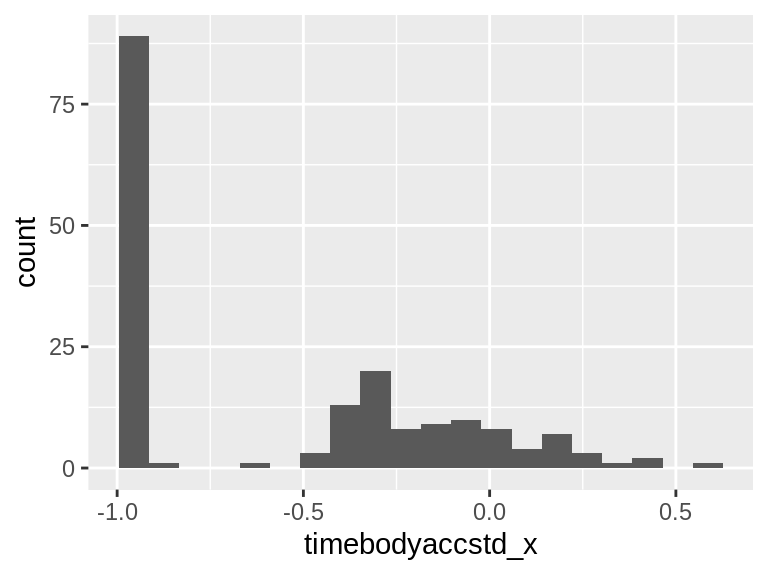

## timebodyaccstd_y

| Feature | Result |
| --- | --- |
| Variable type | numeric |
| Number of missing obs. | 0 (0 %) |
| Number of unique values | 180 |
| Median | -0.51 |
| 1st and 3rd quartiles | -0.94; -0.03 |
| Min. and max. | -0.99; 0.62 |

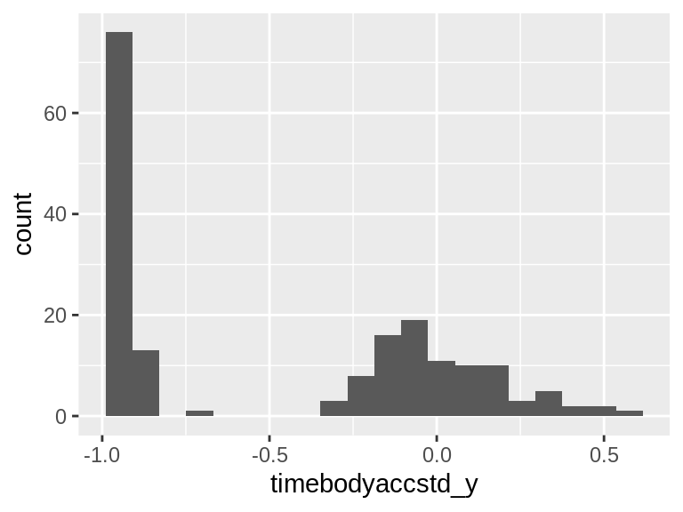

## timebodyaccstd_z

| Feature | Result |
| --- | --- |
| Variable type | numeric |
| Number of missing obs. | 0 (0 %) |
| Number of unique values | 180 |
| Median | -0.65 |
| 1st and 3rd quartiles | -0.95; -0.23 |
| Min. and max. | -0.99; 0.61 |

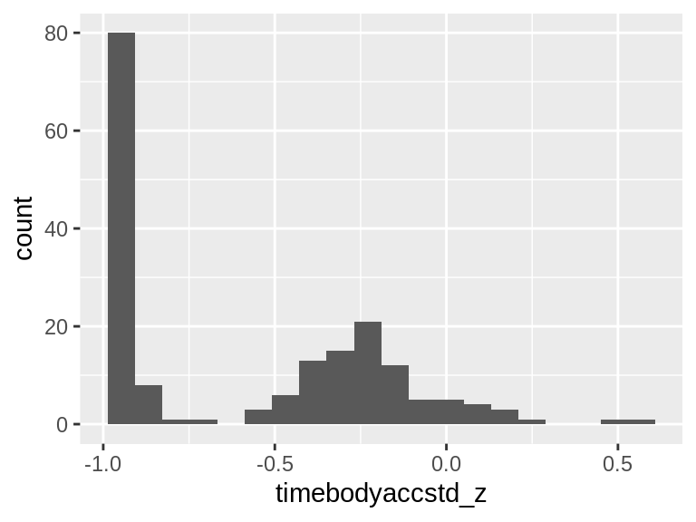

## timegravityaccmean_x

| Feature | Result |
| --- | --- |
| Variable type | numeric |
| Number of missing obs. | 0 (0 %) |
| Number of unique values | 180 |
| Median | 0.92 |
| 1st and 3rd quartiles | 0.84; 0.94 |
| Min. and max. | -0.68; 0.97 |

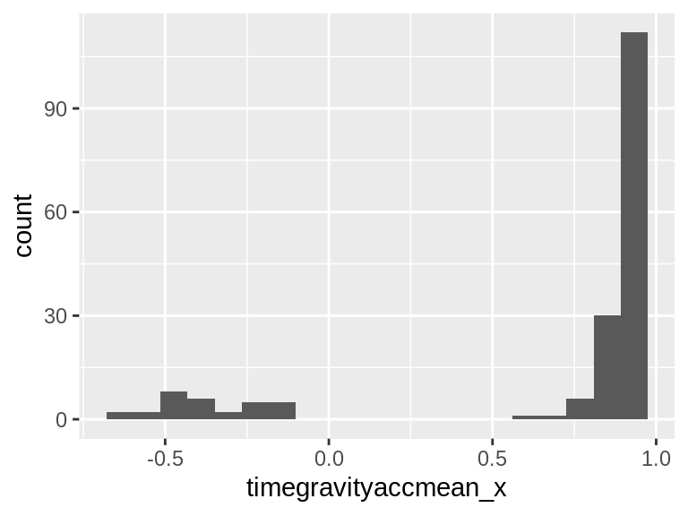

- Note that the following possible outlier values were detected: "-0.68", "-0.62", "-0.58", "-0.53", "-0.51", "-0.5", "-0.49", "-0.48", "-0.48", "-0.47" (37 additional values omitted).

## timegravityaccmean_y

| Feature | Result |
| --- | --- |
| Variable type | numeric |
| Number of missing obs. | 0 (0 %) |
| Number of unique values | 180 |
| Median | -0.13 |
| 1st and 3rd quartiles | -0.23; 0.09 |
| Min. and max. | -0.48; 0.96 |

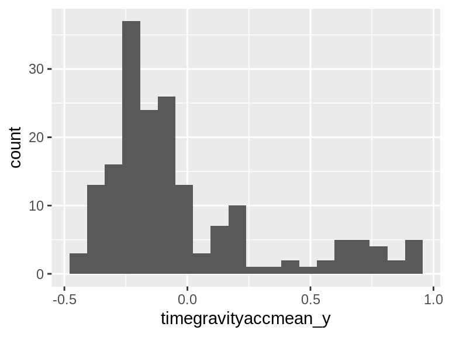

- Note that the following possible outlier values were detected: "-0.48", "-0.43", "-0.42", "-0.39", "-0.38", "-0.37", "-0.37", "-0.36".

## timegravityaccmean_z

| Feature | Result |
| --- | --- |
| Variable type | numeric |
| Number of missing obs. | 0 (0 %) |
| Number of unique values | 180 |
| Median | 0.02 |
| 1st and 3rd quartiles | -0.12; 0.15 |
| Min. and max. | -0.5; 0.96 |

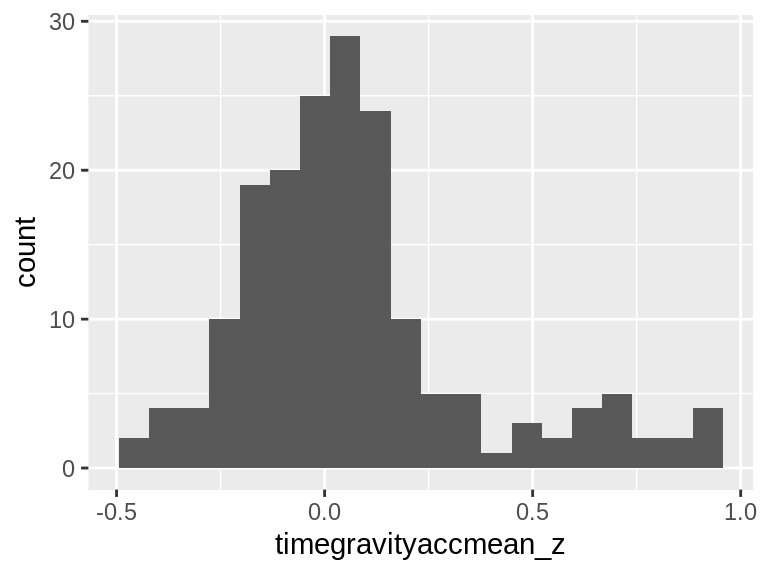

- Note that the following possible outlier values were detected: "-0.5", "-0.42", "-0.4", "-0.39", "-0.38", "0.72", "0.72", "0.77", "0.79", "0.84" (5 additional values omitted).

## timegravityaccstd_x

| Feature | Result |
| --- | --- |
| Variable type | numeric |
| Number of missing obs. | 0 (0 %) |
| Number of unique values | 180 |
| Median | -0.97 |
| 1st and 3rd quartiles | -0.98; -0.95 |
| Min. and max. | -1; -0.83 |

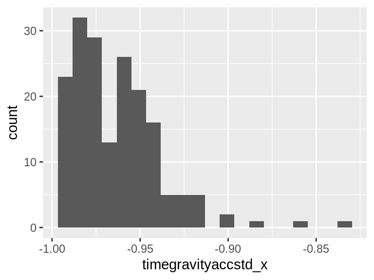

- Note that the following possible outlier values were detected: "-0.83".

## timegravityaccstd_y

| Feature | Result |
| --- | --- |
| Variable type | numeric |
| Number of missing obs. | 0 (0 %) |
| Number of unique values | 180 |
| Median | -0.96 |
| 1st and 3rd quartiles | -0.97; -0.94 |
| Min. and max. | -0.99; -0.64 |

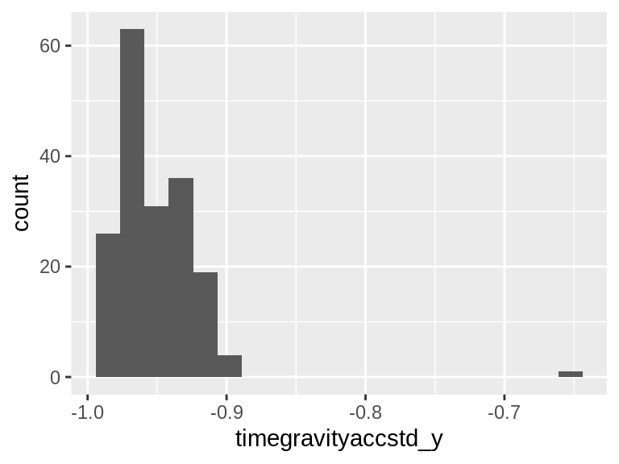

- Note that the following possible outlier values were detected: "-0.99", "-0.99", "-0.99", "-0.99", "-0.99", "-0.99", "-0.64".

## timegravityaccstd_z

| Feature | Result |
| --- | --- |
| Variable type | numeric |
| Number of missing obs. | 0 (0 %) |
| Number of unique values | 180 |
| Median | -0.95 |
| 1st and 3rd quartiles | -0.96; -0.92 |
| Min. and max. | -0.99; -0.61 |

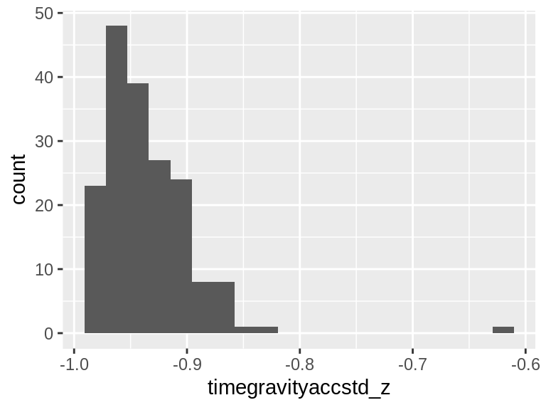

- Note that the following possible outlier values were detected: "-0.99", "-0.99", "-0.99", "-0.99", "-0.99", "-0.98", "-0.98", "-0.98", "-0.98", "-0.61".

## timebodyaccjerkmean_x

| Feature | Result |
| --- | --- |
| Variable type | numeric |
| Number of missing obs. | 0 (0 %) |
| Number of unique values | 180 |
| Median | 0.08 |
| 1st and 3rd quartiles | 0.07; 0.08 |
| Min. and max. | 0.04; 0.13 |

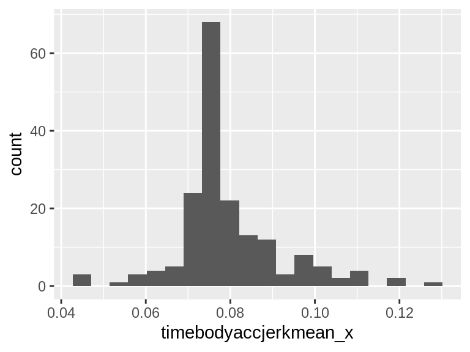

- Note that the following possible outlier values were detected: "0.04", "0.04", "0.05", "0.05", "0.06", "0.06", "0.06", "0.06", "0.06", "0.06" (14 additional values omitted).

## timebodyaccjerkmean_y

| Feature | Result |
| --- | --- |
| Variable type | numeric |
| Number of missing obs. | 0 (0 %) |
| Number of unique values | 180 |
| Median | 0.01 |
| 1st and 3rd quartiles | 0; 0.01 |
| Min. and max. | -0.04; 0.06 |

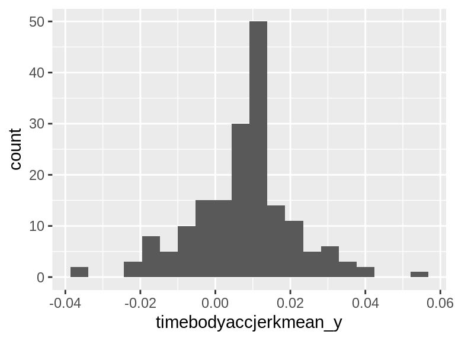

- Note that the following possible outlier values were detected: "0.02", "0.02", "0.02", "0.02", "0.02", "0.02", "0.02", "0.02", "0.02", "0.02" (16 additional values omitted).

## timebodyaccjerkmean_z

| Feature | Result |
| --- | --- |
| Variable type | numeric |
| Number of missing obs. | 0 (0 %) |
| Number of unique values | 180 |
| Median | 0 |
| 1st and 3rd quartiles | -0.01; 0 |
| Min. and max. | -0.07; 0.04 |

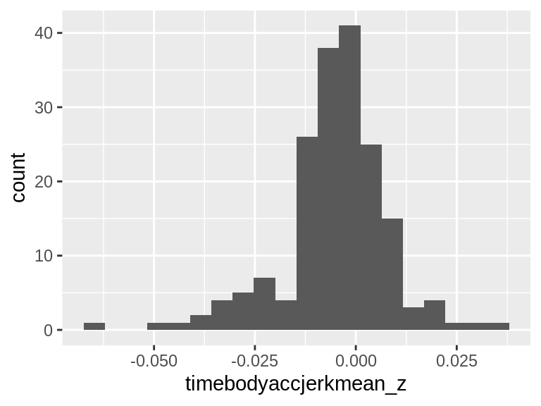

- Note that the following possible outlier values were detected: "-0.07", "-0.05", "-0.05", "-0.04", "-0.04", "-0.03", "0.02", "0.02", "0.02", "0.02" (3 additional values omitted).

## timebodyaccjerkstd_x

| Feature | Result |
| --- | --- |
| Variable type | numeric |
| Number of missing obs. | 0 (0 %) |
| Number of unique values | 180 |
| Median | -0.81 |
| 1st and 3rd quartiles | -0.98; -0.22 |
| Min. and max. | -0.99; 0.54 |

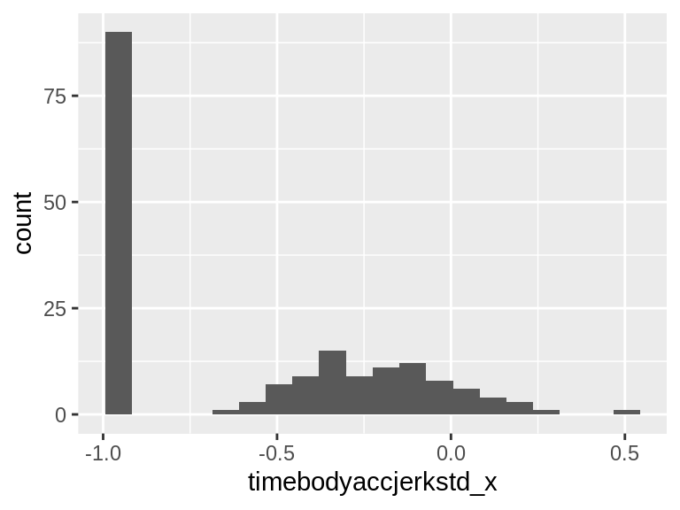

## timebodyaccjerkstd_y

| Feature | Result |
| --- | --- |
| Variable type | numeric |
| Number of missing obs. | 0 (0 %) |
| Number of unique values | 180 |
| Median | -0.78 |
| 1st and 3rd quartiles | -0.97; -0.15 |
| Min. and max. | -0.99; 0.36 |

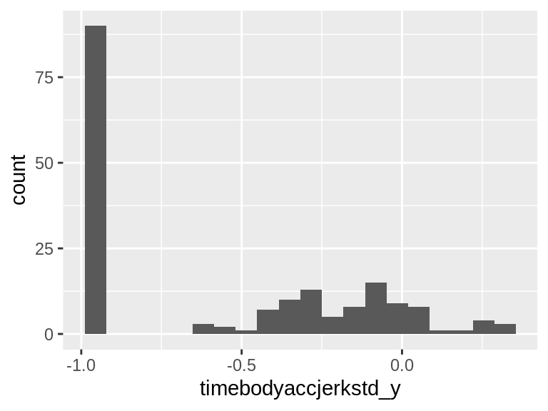

## timebodyaccjerkstd_z

| Feature | Result |
| --- | --- |
| Variable type | numeric |
| Number of missing obs. | 0 (0 %) |
| Number of unique values | 180 |
| Median | -0.88 |
| 1st and 3rd quartiles | -0.98; -0.51 |
| Min. and max. | -0.99; 0.03 |

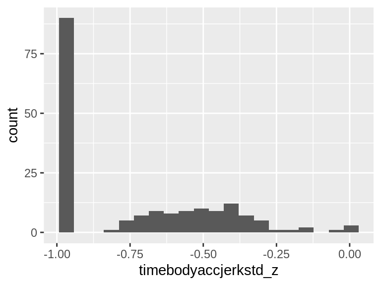

## timebodygyromean_x

| Feature | Result |
| --- | --- |
| Variable type | numeric |
| Number of missing obs. | 0 (0 %) |
| Number of unique values | 180 |
| Median | -0.03 |
| 1st and 3rd quartiles | -0.05; -0.02 |
| Min. and max. | -0.21; 0.19 |

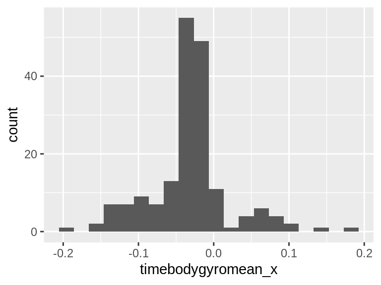

- Note that the following possible outlier values were detected: "-0.21", "-0.16", "-0.16", "-0.14", "-0.14", "-0.14", "-0.14", "0", "0", "0.01" (21 additional values omitted).

## timebodygyromean_y

| Feature | Result |
| --- | --- |
| Variable type | numeric |
| Number of missing obs. | 0 (0 %) |
| Number of unique values | 180 |
| Median | -0.07 |
| 1st and 3rd quartiles | -0.09; -0.06 |
| Min. and max. | -0.2; 0.03 |

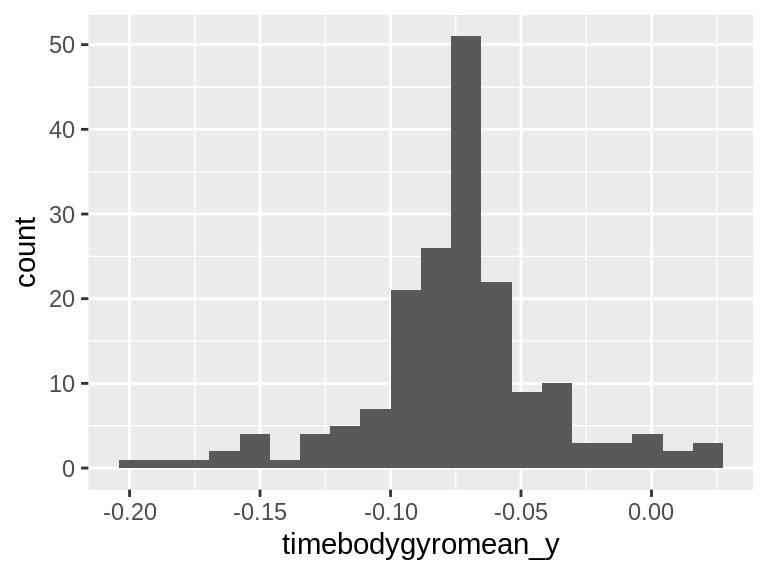

- Note that the following possible outlier values were detected: "-0.2", "-0.18", "-0.17", "-0.17", "-0.16", "-0.16", "-0.15", "-0.15", "-0.15", "-0.14" (13 additional values omitted).

## timebodygyromean_z

| Feature | Result |
| --- | --- |
| Variable type | numeric |
| Number of missing obs. | 0 (0 %) |
| Number of unique values | 180 |
| Median | 0.09 |
| 1st and 3rd quartiles | 0.07; 0.1 |
| Min. and max. | -0.07; 0.18 |

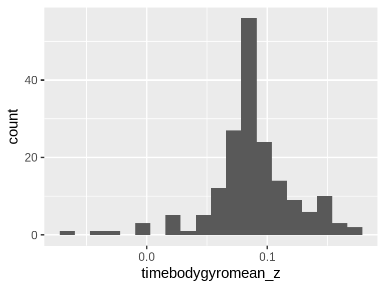

- Note that the following possible outlier values were detected: "-0.07", "-0.04", "-0.03", "-0.01", "-0.01", "0", "0.02", "0.02", "0.02", "0.02" (10 additional values omitted).

## timebodygyrostd_x

| Feature | Result |
| --- | --- |
| Variable type | numeric |
| Number of missing obs. | 0 (0 %) |
| Number of unique values | 180 |
| Median | -0.79 |
| 1st and 3rd quartiles | -0.97; -0.44 |
| Min. and max. | -0.99; 0.27 |

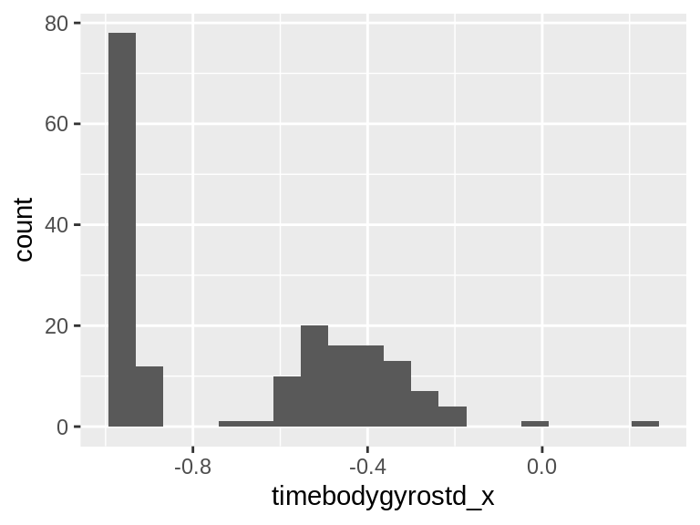

## timebodygyrostd_y

| Feature | Result |
| --- | --- |
| Variable type | numeric |
| Number of missing obs. | 0 (0 %) |
| Number of unique values | 180 |
| Median | -0.8 |
| 1st and 3rd quartiles | -0.96; -0.42 |
| Min. and max. | -0.99; 0.48 |

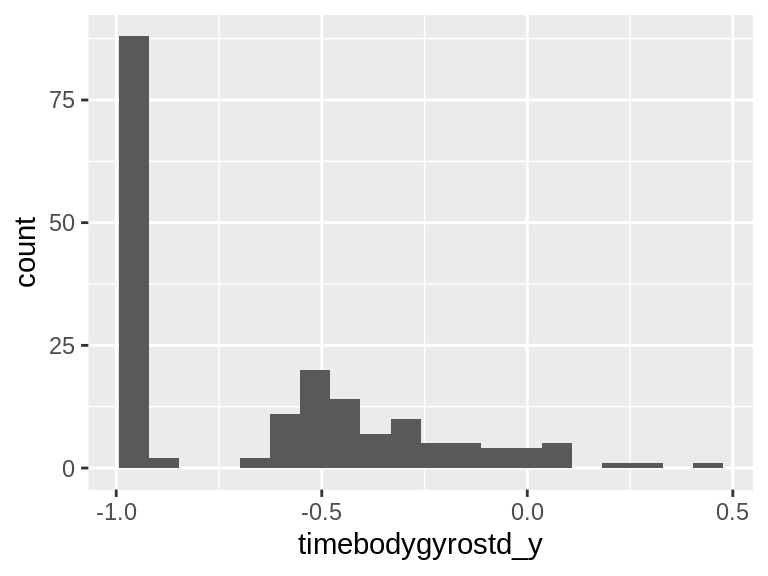

## timebodygyrostd_z

| Feature | Result |
| --- | --- |
| Variable type | numeric |
| Number of missing obs. | 0 (0 %) |
| Number of unique values | 180 |
| Median | -0.8 |
| 1st and 3rd quartiles | -0.96; -0.31 |
| Min. and max. | -0.99; 0.56 |

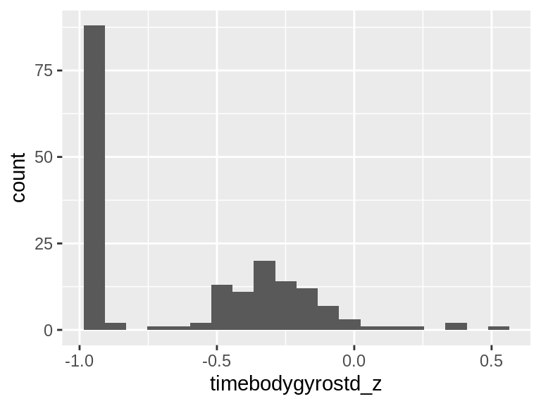

## timebodygyrojerkmean_x

| Feature | Result |
| --- | --- |
| Variable type | numeric |
| Number of missing obs. | 0 (0 %) |
| Number of unique values | 180 |
| Median | -0.1 |
| 1st and 3rd quartiles | -0.1; -0.09 |
| Min. and max. | -0.16; -0.02 |

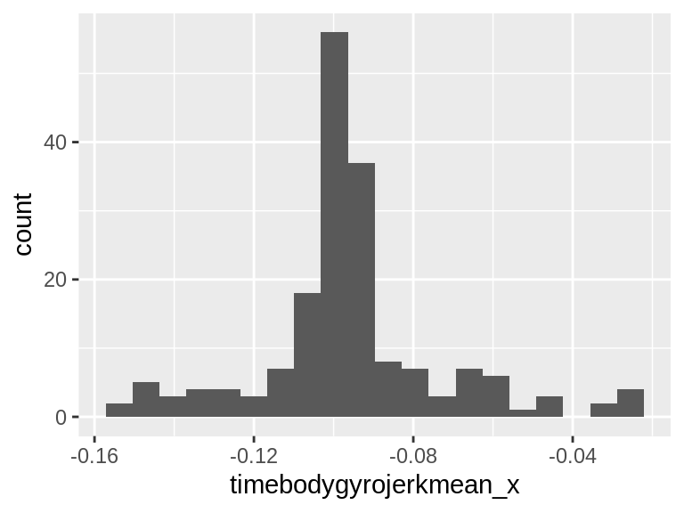

- Note that the following possible outlier values were detected: "-0.16", "-0.16", "-0.15", "-0.15", "-0.15", "-0.14", "-0.14", "-0.14", "-0.14", "-0.14" (26 additional values omitted).

## timebodygyrojerkmean_y

| Feature | Result |
| --- | --- |
| Variable type | numeric |
| Number of missing obs. | 0 (0 %) |
| Number of unique values | 180 |
| Median | -0.04 |
| 1st and 3rd quartiles | -0.05; -0.04 |
| Min. and max. | -0.08; -0.01 |

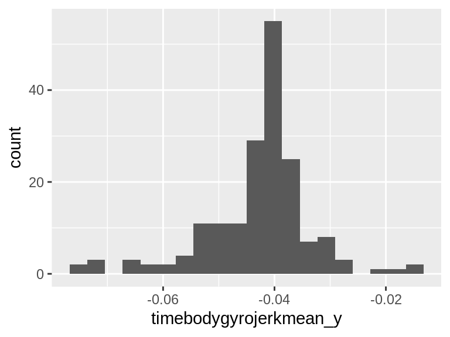

- Note that the following possible outlier values were detected: "-0.08", "-0.07", "-0.07", "-0.07", "-0.07", "-0.07", "-0.07", "-0.03", "-0.03", "-0.03" (14 additional values omitted).

## timebodygyrojerkmean_z

| Feature | Result |
| --- | --- |
| Variable type | numeric |
| Number of missing obs. | 0 (0 %) |
| Number of unique values | 180 |
| Median | -0.05 |
| 1st and 3rd quartiles | -0.06; -0.05 |
| Min. and max. | -0.09; -0.01 |

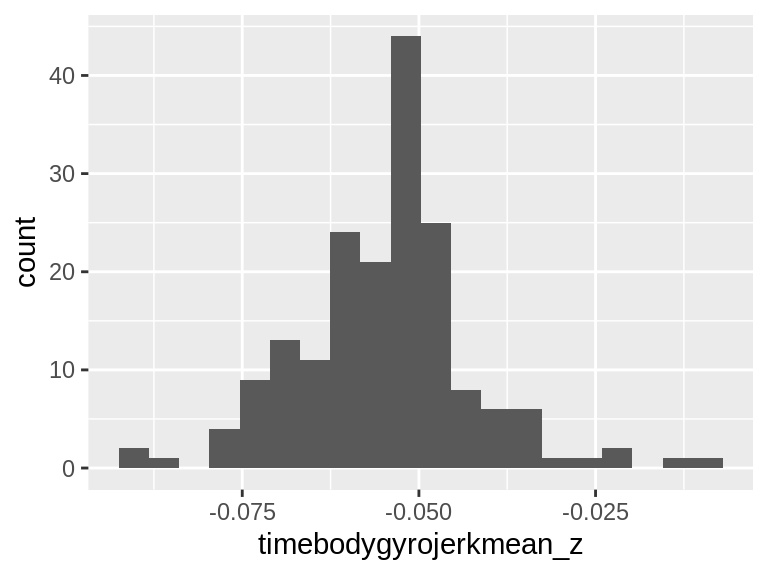

- Note that the following possible outlier values were detected: "-0.04", "-0.04", "-0.04", "-0.04", "-0.04", "-0.04", "-0.04", "-0.04", "-0.04", "-0.04" (12 additional values omitted).

## timebodygyrojerkstd_x

| Feature | Result |
| --- | --- |
| Variable type | numeric |
| Number of missing obs. | 0 (0 %) |
| Number of unique values | 180 |
| Median | -0.84 |
| 1st and 3rd quartiles | -0.98; -0.46 |
| Min. and max. | -1; 0.18 |

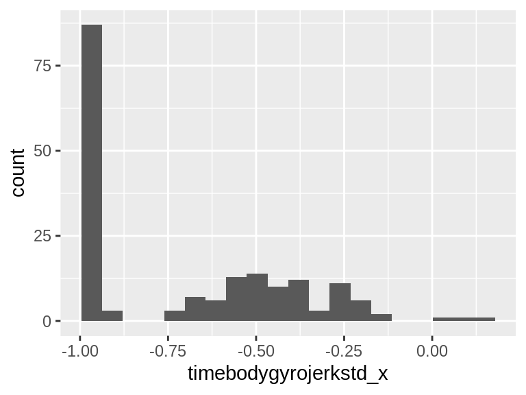